# Transportation Trips & Cost: Subgroup File, City

Author

Tina Chelidze

Published

April 25, 2024

*2023-2024 Mobility Metrics update*

SUBGROUP-LEVEL VALUES

Raw data pulled from https://htaindex.cnt.org/download/ The Housing and Transportation (H+T) Affordability Index from the Center for Neighborhood Technology (CNT)

*User Notice: This program requires downloading raw files from the Metrics_2024_round Box folder prior to running. See details under the Read Data section.*

## Housekeeping

Read in packages for use.

```r
library(tidyr)
library(dplyr)
library(readr)
library(ggplot2)
library(tidyverse)
library(purrr)
library(tidycensus)
```

## Read data

The data from HUD cannot be easily read directly into this program. Before running, please download the entirety of the folders listed below from the following [Box folder](https://urbanorg.app.box.com/folder/250262697073) into the repository folder. You may be required to unzip the folders but keep the raw files in their folders. `"mobility-from-poverty\06_neighborhoods\Transportation\data"`

- 2015_tract
- 2019_tract

### 2015

Bring in all the downloaded CSVs (state-level tracts) & combine them into one nation-wide file for tracts.

```r
tracts15files <- list.files(path = here::here("06_neighborhoods",
                                             "Transportation",
                                             "data",
                                             "2015_tract"), pattern = "*.csv")
print(tracts15files)
```

```
 [1] "htaindex2015_data_tracts_01.csv" "htaindex2015_data_tracts_02.csv"
 [3] "htaindex2015_data_tracts_04.csv" "htaindex2015_data_tracts_05.csv"
 [5] "htaindex2015_data_tracts_06.csv" "htaindex2015_data_tracts_08.csv"
 [7] "htaindex2015_data_tracts_09.csv" "htaindex2015_data_tracts_10.csv"
 [9] "htaindex2015_data_tracts_11.csv" "htaindex2015_data_tracts_12.csv"
[11] "htaindex2015_data_tracts_13.csv" "htaindex2015_data_tracts_15.csv"
[13] "htaindex2015_data_tracts_16.csv" "htaindex2015_data_tracts_17.csv"
[15] "htaindex2015_data_tracts_18.csv" "htaindex2015_data_tracts_19.csv"
[17] "htaindex2015_data_tracts_20.csv" "htaindex2015_data_tracts_21.csv"
[19] "htaindex2015_data_tracts_22.csv" "htaindex2015_data_tracts_23.csv"
[21] "htaindex2015_data_tracts_24.csv" "htaindex2015_data_tracts_25.csv"
[23] "htaindex2015_data_tracts_26.csv" "htaindex2015_data_tracts_27.csv"
[25] "htaindex2015_data_tracts_28.csv" "htaindex2015_data_tracts_29.csv"
[27] "htaindex2015_data_tracts_30.csv" "htaindex2015_data_tracts_31.csv"
[29] "htaindex2015_data_tracts_32.csv" "htaindex2015_data_tracts_33.csv"
[31] "htaindex2015_data_tracts_34.csv" "htaindex2015_data_tracts_35.csv"
[33] "htaindex2015_data_tracts_36.csv" "htaindex2015_data_tracts_37.csv"
[35] "htaindex2015_data_tracts_38.csv" "htaindex2015_data_tracts_39.csv"
[37] "htaindex2015_data_tracts_40.csv" "htaindex2015_data_tracts_41.csv"
[39] "htaindex2015_data_tracts_42.csv" "htaindex2015_data_tracts_44.csv"
[41] "htaindex2015_data_tracts_45.csv" "htaindex2015_data_tracts_46.csv"
[43] "htaindex2015_data_tracts_47.csv" "htaindex2015_data_tracts_48.csv"
[45] "htaindex2015_data_tracts_49.csv" "htaindex2015_data_tracts_50.csv"
[47] "htaindex2015_data_tracts_51.csv" "htaindex2015_data_tracts_53.csv"
[49] "htaindex2015_data_tracts_54.csv" "htaindex2015_data_tracts_55.csv"
[51] "htaindex2015_data_tracts_56.csv"
```

```r
tractpath15 = file.path(here::here("06_neighborhoods",
                                             "Transportation",
                                             "data",
                                             "2015_tract"), tracts15files)
print(tractpath15)
```

```
 [1] "V:/Centers/HFP/JWalsh/mobility-from-poverty/06_neighborhoods/Transportation/data/2015_tract/htaindex2015_data_tracts_01.csv"
 [2] "V:/Centers/HFP/JWalsh/mobility-from-poverty/06_neighborhoods/Transportation/data/2015_tract/htaindex2015_data_tracts_02.csv"
 [3] "V:/Centers/HFP/JWalsh/mobility-from-poverty/06_neighborhoods/Transportation/data/2015_tract/htaindex2015_data_tracts_04.csv"
 [4] "V:/Centers/HFP/JWalsh/mobility-from-poverty/06_neighborhoods/Transportation/data/2015_tract/htaindex2015_data_tracts_05.csv"
 [5] "V:/Centers/HFP/JWalsh/mobility-from-poverty/06_neighborhoods/Transportation/data/2015_tract/htaindex2015_data_tracts_06.csv"
 [6] "V:/Centers/HFP/JWalsh/mobility-from-poverty/06_neighborhoods/Transportation/data/2015_tract/htaindex2015_data_tracts_08.csv"
 [7] "V:/Centers/HFP/JWalsh/mobility-from-poverty/06_neighborhoods/Transportation/data/2015_tract/htaindex2015_data_tracts_09.csv"
 [8] "V:/Centers/HFP/JWalsh/mobility-from-poverty/06_neighborhoods/Transportation/data/2015_tract/htaindex2015_data_tracts_10.csv"
 [9] "V:/Centers/HFP/JWalsh/mobility-from-poverty/06_neighborhoods/Transportation/data/2015_tract/htaindex2015_data_tracts_11.csv"
[10] "V:/Centers/HFP/JWalsh/mobility-from-poverty/06_neighborhoods/Transportation/data/2015_tract/htaindex2015_data_tracts_12.csv"
[11] "V:/Centers/HFP/JWalsh/mobility-from-poverty/06_neighborhoods/Transportation/data/2015_tract/htaindex2015_data_tracts_13.csv"
[12] "V:/Centers/HFP/JWalsh/mobility-from-poverty/06_neighborhoods/Transportation/data/2015_tract/htaindex2015_data_tracts_15.csv"
[13] "V:/Centers/HFP/JWalsh/mobility-from-poverty/06_neighborhoods/Transportation/data/2015_tract/htaindex2015_data_tracts_16.csv"
[14] "V:/Centers/HFP/JWalsh/mobility-from-poverty/06_neighborhoods/Transportation/data/2015_tract/htaindex2015_data_tracts_17.csv"
[15] "V:/Centers/HFP/JWalsh/mobility-from-poverty/06_neighborhoods/Transportation/data/2015_tract/htaindex2015_data_tracts_18.csv"
```

[output cut: 36 more lines]

```r
transport_tracts_2015 <- map_df(tractpath15, read_csv)
```

Create correct FIPS columns.

```r
transport_tracts_2015 <- transport_tracts_2015 %>%
  rename (GEOID = tract) %>%
  mutate(
    state = substr(GEOID, start = 2, stop = 3),
    county = substr(GEOID, start = 4, stop = 6),
    tract = substr(GEOID, start = 7, stop = 12)
  )
```

Keep only variables of interest.

```r
transit_trips_tracts_2015 <- transport_tracts_2015 %>%
  select(GEOID, state, county, tract, blkgrps, population, households, transit_trips_80ami)
transit_cost_tracts_2015 <- transport_tracts_2015 %>%
  select(GEOID, state, county, tract, blkgrps, population, households, t_80ami)
```

### 2019

Bring in all the downloaded CSVs (state-level tracts) & combine them into one nation-wide file for tracts.

```r
tracts19files <- list.files(path = here::here("06_neighborhoods",
                                             "Transportation",
                                             "data",
                                             "2019_tract"), pattern = "*.csv")
print(tracts19files)
```

```
 [1] "htaindex2019_data_tracts_01.csv" "htaindex2019_data_tracts_02.csv"
 [3] "htaindex2019_data_tracts_04.csv" "htaindex2019_data_tracts_05.csv"
 [5] "htaindex2019_data_tracts_06.csv" "htaindex2019_data_tracts_08.csv"
 [7] "htaindex2019_data_tracts_09.csv" "htaindex2019_data_tracts_10.csv"
 [9] "htaindex2019_data_tracts_11.csv" "htaindex2019_data_tracts_12.csv"
[11] "htaindex2019_data_tracts_13.csv" "htaindex2019_data_tracts_15.csv"
[13] "htaindex2019_data_tracts_16.csv" "htaindex2019_data_tracts_17.csv"
[15] "htaindex2019_data_tracts_18.csv" "htaindex2019_data_tracts_19.csv"
[17] "htaindex2019_data_tracts_20.csv" "htaindex2019_data_tracts_21.csv"
[19] "htaindex2019_data_tracts_22.csv" "htaindex2019_data_tracts_23.csv"
[21] "htaindex2019_data_tracts_24.csv" "htaindex2019_data_tracts_25.csv"
[23] "htaindex2019_data_tracts_26.csv" "htaindex2019_data_tracts_27.csv"
[25] "htaindex2019_data_tracts_28.csv" "htaindex2019_data_tracts_29.csv"
[27] "htaindex2019_data_tracts_30.csv" "htaindex2019_data_tracts_31.csv"
[29] "htaindex2019_data_tracts_32.csv" "htaindex2019_data_tracts_33.csv"
[31] "htaindex2019_data_tracts_34.csv" "htaindex2019_data_tracts_35.csv"
[33] "htaindex2019_data_tracts_36.csv" "htaindex2019_data_tracts_37.csv"
[35] "htaindex2019_data_tracts_38.csv" "htaindex2019_data_tracts_39.csv"
[37] "htaindex2019_data_tracts_40.csv" "htaindex2019_data_tracts_41.csv"
[39] "htaindex2019_data_tracts_42.csv" "htaindex2019_data_tracts_44.csv"
[41] "htaindex2019_data_tracts_45.csv" "htaindex2019_data_tracts_46.csv"
[43] "htaindex2019_data_tracts_47.csv" "htaindex2019_data_tracts_48.csv"
[45] "htaindex2019_data_tracts_49.csv" "htaindex2019_data_tracts_50.csv"
[47] "htaindex2019_data_tracts_51.csv" "htaindex2019_data_tracts_53.csv"
[49] "htaindex2019_data_tracts_54.csv" "htaindex2019_data_tracts_55.csv"
[51] "htaindex2019_data_tracts_56.csv"
```

```r
tractpath19 = file.path(here::here("06_neighborhoods",
                                             "Transportation",
                                             "data",
                                             "2019_tract"), tracts19files)
print(tractpath19)
```

```
 [1] "V:/Centers/HFP/JWalsh/mobility-from-poverty/06_neighborhoods/Transportation/data/2019_tract/htaindex2019_data_tracts_01.csv"
 [2] "V:/Centers/HFP/JWalsh/mobility-from-poverty/06_neighborhoods/Transportation/data/2019_tract/htaindex2019_data_tracts_02.csv"
 [3] "V:/Centers/HFP/JWalsh/mobility-from-poverty/06_neighborhoods/Transportation/data/2019_tract/htaindex2019_data_tracts_04.csv"
 [4] "V:/Centers/HFP/JWalsh/mobility-from-poverty/06_neighborhoods/Transportation/data/2019_tract/htaindex2019_data_tracts_05.csv"
 [5] "V:/Centers/HFP/JWalsh/mobility-from-poverty/06_neighborhoods/Transportation/data/2019_tract/htaindex2019_data_tracts_06.csv"
 [6] "V:/Centers/HFP/JWalsh/mobility-from-poverty/06_neighborhoods/Transportation/data/2019_tract/htaindex2019_data_tracts_08.csv"
 [7] "V:/Centers/HFP/JWalsh/mobility-from-poverty/06_neighborhoods/Transportation/data/2019_tract/htaindex2019_data_tracts_09.csv"
 [8] "V:/Centers/HFP/JWalsh/mobility-from-poverty/06_neighborhoods/Transportation/data/2019_tract/htaindex2019_data_tracts_10.csv"
 [9] "V:/Centers/HFP/JWalsh/mobility-from-poverty/06_neighborhoods/Transportation/data/2019_tract/htaindex2019_data_tracts_11.csv"
[10] "V:/Centers/HFP/JWalsh/mobility-from-poverty/06_neighborhoods/Transportation/data/2019_tract/htaindex2019_data_tracts_12.csv"
[11] "V:/Centers/HFP/JWalsh/mobility-from-poverty/06_neighborhoods/Transportation/data/2019_tract/htaindex2019_data_tracts_13.csv"
[12] "V:/Centers/HFP/JWalsh/mobility-from-poverty/06_neighborhoods/Transportation/data/2019_tract/htaindex2019_data_tracts_15.csv"
[13] "V:/Centers/HFP/JWalsh/mobility-from-poverty/06_neighborhoods/Transportation/data/2019_tract/htaindex2019_data_tracts_16.csv"
[14] "V:/Centers/HFP/JWalsh/mobility-from-poverty/06_neighborhoods/Transportation/data/2019_tract/htaindex2019_data_tracts_17.csv"
[15] "V:/Centers/HFP/JWalsh/mobility-from-poverty/06_neighborhoods/Transportation/data/2019_tract/htaindex2019_data_tracts_18.csv"
```

[output cut: 36 more lines]

```r
transport_tracts_2019 <- map_df(tractpath19, read_csv)
```

Create correct FIPS columns.

```r
transport_tracts_2019 <- transport_tracts_2019 %>%
  rename (GEOID = tract) %>%
  mutate(
    state = substr(GEOID, start = 2, stop = 3),
    county = substr(GEOID, start = 4, stop = 6),
    tract = substr(GEOID, start = 7, stop = 12)
  )
```

Keep only variables of interest.

```r
transit_trips_tracts_2019 <- transport_tracts_2019 %>%
  select(GEOID, state, county, tract, blkgrps, population, households, transit_trips_80ami)
transit_cost_tracts_2019 <- transport_tracts_2019 %>%
  select(GEOID, state, county, tract, blkgrps, population, households, t_80ami)
```

## Race-Ethnicity work

Create breakout by race/ethnicity.

### Read ACS population by race

Pull in that year’s population by race via ACS (tract-level)

```r
ACSvars2015 <- load_variables(2015, "acs5", cache = TRUE)
ACSvars2019 <- load_variables(2019, "acs5", cache = TRUE)
```

- Variables we want:
- B02001_001 Total Pop Estimate
- B02001_002 White alone
- B02001_003 Black or AfAm alone
- B02001_004 Am Indian & Alaska Native alone
- B02001_005 Asian alone
- B02001_006 Native Hawaiian, Pacific Islander alone
- B02001_007 Some other race alone
- B02001_008 Two or more races

```r
my_states <- fips_codes %>%
  filter(!state %in% c("PR", "UM", "VI", "GU", "AS", "MP")) %>%
  pull(state) %>%
  unique()

acs_tract_pop15 <- map_dfr(
  my_states,
  ~ get_acs(
    geography = "tract",
    state = .,
    table = "B02001",
    year = 2015,
    survey = "acs5",
    output = "wide"
  )
)
```

Rename columns for clarity

```r
acs_tract_pop15 <- acs_tract_pop15 %>%
  rename(total_population = B02001_001E,
         white_population = B02001_002E,
         black_population = B02001_003E,
         asian_population = B02001_005E,
         aian_population = B02001_004E,
         nhpi_population = B02001_006E,
         other_population = B02001_007E
  )
```

```r
acs_tract_pop19 <- map_dfr(
  my_states,
  ~ get_acs(
    geography = "tract",
    state = .,
    table = "B02001",
    year = 2019,
    survey = "acs5",
    output = "wide"
  )
)
```

```r
acs_tract_pop19 <- acs_tract_pop19 %>%
  rename(total_population = B02001_001E,
         white_population = B02001_002E,
         black_population = B02001_003E,
         asian_population = B02001_005E,
         aian_population = B02001_004E,
         nhpi_population = B02001_006E,
         other_population = B02001_007E
  )
```

Keep only vars we want.

```r
acs_tract_pop15 <- acs_tract_pop15 %>%
  select(GEOID, total_population, white_population, black_population,
         asian_population, aian_population, nhpi_population, other_population)
acs_tract_pop19 <- acs_tract_pop19 %>%
  select(GEOID, total_population, white_population, black_population,
         asian_population, aian_population, nhpi_population, other_population)
```

Note that this is 73,056 observations in the ACS data That means we will have 317 missing tract values in 2015 (73056 - 72739), and 314 missing tract values in the 2019 data (72056 - 72742)

Join the transit data with the ACS population data, first, prep GEOID in the transit data for join purposes.

```r
transit_cost_tracts_2015$GEOID <- paste0(transit_cost_tracts_2015$state, transit_cost_tracts_2015$county, transit_cost_tracts_2015$tract)
transit_cost_tracts_2019$GEOID <- paste0(transit_cost_tracts_2019$state, transit_cost_tracts_2019$county, transit_cost_tracts_2019$tract)
transit_trips_tracts_2015$GEOID <- paste0(transit_trips_tracts_2015$state, transit_trips_tracts_2015$county, transit_trips_tracts_2015$tract)
transit_trips_tracts_2019$GEOID <- paste0(transit_trips_tracts_2019$state, transit_trips_tracts_2019$county, transit_trips_tracts_2019$tract)
```

Merge population data with transit data files (4 of them)

### FIRST ONE - Cost in 2015

```r
cost_data_2015 <- left_join(acs_tract_pop15, transit_cost_tracts_2015, by = "GEOID")
```

Test with anti_join to make sure it worked properly

```r
#stopifnot(
#  anti_join(acs_tract_pop15, transit_cost_tracts_2015, by = "GEOID") %>%
#    nrow() == 0
#)
```

Error - therefore, check how many missing cost values for observations where we have population

```r
missing_count <- sum(is.na(cost_data_2015$t_80ami))

cat("Number of missing values for t_80ami:", missing_count, "\n")
```

```
Number of missing values for t_80ami: 810
```

810 missing values.

### SECOND ONE - Cost in 2019

```r
cost_data_2019 <- left_join(acs_tract_pop19, transit_cost_tracts_2019, by = "GEOID")
```

Test with anti_join to make sure it worked properly

```r
#stopifnot(
#  anti_join(acs_tract_pop19, transit_cost_tracts_2019, by = "GEOID") %>%
#    nrow() == 0
#)
```

Error - therefore, check how many missing cost values for observations where we have population

```r
missing_count <- sum(is.na(cost_data_2019$t_80ami))

cat("Number of missing values for t_80ami:", missing_count, "\n")
```

```
Number of missing values for t_80ami: 831
```

831 missing values.

### THIRD ONE - Trips in 2015

```r
trips_data_2015 <- left_join(acs_tract_pop15, transit_trips_tracts_2015, by = "GEOID")
```

Test with anti_join to make sure it worked properly

```r
#stopifnot(
#  anti_join(acs_tract_pop15, transit_trips_tracts_2015, by = "GEOID") %>%
#    nrow() == 0
#)
```

Error - therefore, check how many missing trips values for observations where we have population.

```r
missing_count <- sum(is.na(trips_data_2015$transit_trips_80ami))
cat("Number of missing values for transit_trips_80ami:", missing_count, "\n")
```

```
Number of missing values for transit_trips_80ami: 810
```

810 missing values - aligns with cost data for the same year, good.

### FOURTH ONE - Trips in 2019

```r
trips_data_2019 <- left_join(acs_tract_pop19, transit_trips_tracts_2019, by = "GEOID")
```

Test with anti_join to make sure it worked properly

```r
#stopifnot(
#  anti_join(acs_tract_pop19, transit_trips_tracts_2019, by = "GEOID") %>%
#    nrow() == 0
#)
```

Error - therefore, check how many missing trips values for observations where we have population

```r
missing_count <- sum(is.na(trips_data_2019$transit_trips_80ami))
cat("Number of missing values for transit_trips_80ami:", missing_count, "\n")
```

```
Number of missing values for transit_trips_80ami: 831
```

831 missing values - aligns with cost data for the same year, good

### Create race category

For each tract, ID the race category

Calculate the percentage of total population for White & POC for each tract

```r
cost_data_2015 <- cost_data_2015 %>%
  mutate(
    perc_white = if_else(
      complete.cases(total_population, white_population),
      if_else(population > 0, white_population / total_population, 0),
      NA_real_
    ),
    perc_POC = if_else(
      complete.cases(total_population, black_population, asian_population, aian_population, nhpi_population, other_population),
      if_else(population > 0, ((black_population + asian_population + aian_population + nhpi_population + other_population) / total_population), 0),
      NA_real_
    )
  )
```

```r
cost_data_2019 <- cost_data_2019 %>%
  mutate(
    perc_white = if_else(
      complete.cases(total_population, white_population),
      if_else(population > 0, white_population / total_population, 0),
      NA_real_
    ),
    perc_POC = if_else(
      complete.cases(total_population, black_population, asian_population, aian_population, nhpi_population, other_population),
      if_else(population > 0, ((black_population + asian_population + aian_population + nhpi_population + other_population) / total_population), 0),
      NA_real_
    )
  )
```

```r
trips_data_2015 <- trips_data_2015 %>%
  mutate(
    perc_white = if_else(
      complete.cases(total_population, white_population),
      if_else(population > 0, white_population / total_population, 0),
      NA_real_
    ),
    perc_POC = if_else(
      complete.cases(total_population, black_population, asian_population, aian_population, nhpi_population, other_population),
      if_else(population > 0, ((black_population + asian_population + aian_population + nhpi_population + other_population) / total_population), 0),
      NA_real_
    )
  )
```

```r
trips_data_2019 <- trips_data_2019 %>%
  mutate(
    perc_white = if_else(
      complete.cases(total_population, white_population),
      if_else(population > 0, white_population / total_population, 0),
      NA_real_
    ),
    perc_POC = if_else(
      complete.cases(total_population, black_population, asian_population, aian_population, nhpi_population, other_population),
      if_else(population > 0, ((black_population + asian_population + aian_population + nhpi_population + other_population) / total_population), 0),
      NA_real_
    )
  )
```

Assign race-category for each tract

If 0.6+ White, assign Majority White NH, if 0.6+ POC, assign Predominantly POC 40-60% White or POC, assign No Predominant Racial Group

- subgroup_type=race-ethnicity;
- subgroup=All ZIPs, Majority White-NH Tracts; Majority Non-White Tracts; Mixed Race and Ethnicity Tracts

```r
cost_data_2015 <- cost_data_2015 %>%
  mutate(
    race_category = case_when(
      is.na(perc_white) | is.na(perc_POC) ~ as.character(NA),
      perc_white >= 0.6 ~ "Majority White-NH Tracts",
      perc_POC >= 0.6 ~ "Majority Non-White Tracts",
      perc_white >= 0.4 | perc_POC >= 0.4 ~ "Mixed Race and Ethnicity Tracts",
      perc_white < 0.4 & perc_POC < 0.4 ~ as.character(NA)
    ))
```

```r
cost_data_2019 <- cost_data_2019 %>%
  mutate(
    race_category = case_when(
      is.na(perc_white) | is.na(perc_POC) ~ as.character(NA),
      perc_white >= 0.6 ~ "Majority White-NH Tracts",
      perc_POC >= 0.6 ~ "Majority Non-White Tracts",
      perc_white >= 0.4 | perc_POC >= 0.4 ~ "Mixed Race and Ethnicity Tracts",
      perc_white < 0.4 & perc_POC < 0.4 ~ as.character(NA)
    ))
```

```r
trips_data_2015 <- trips_data_2015 %>%
  mutate(
    race_category = case_when(
      is.na(perc_white) | is.na(perc_POC) ~ as.character(NA),
      perc_white >= 0.6 ~ "Majority White-NH Tracts",
      perc_POC >= 0.6 ~ "Majority Non-White Tracts",
      perc_white >= 0.4 | perc_POC >= 0.4 ~ "Mixed Race and Ethnicity Tracts",
      perc_white < 0.4 & perc_POC < 0.4 ~ as.character(NA)
    ))
```

```r
trips_data_2019 <- trips_data_2019 %>%
  mutate(
    race_category = case_when(
      is.na(perc_white) | is.na(perc_POC) ~ as.character(NA),
      perc_white >= 0.6 ~ "Majority White-NH Tracts",
      perc_POC >= 0.6 ~ "Majority Non-White Tracts",
      perc_white >= 0.4 | perc_POC >= 0.4 ~ "Mixed Race and Ethnicity Tracts",
      perc_white < 0.4 & perc_POC < 0.4 ~ as.character(NA)
    ))
```

## Create all values

Collapse to the CITY level to create ALL values (to be appended later)

FIRST: Bring in the needed crosswalks

2015 place-tract, 2019 place-tract are both covered by our 2018 tract to place crosswalk, since tract designations are only updated on the decade (e.g., 2010, 2020)

```r
tract_place <- read_csv(here::here("geographic-crosswalks",
                                   "data",
                                   "geocorr2018_tract_to_place.csv"))
```

Remove the decimal from the tract variable

```r
tract_place <- tract_place %>%
  mutate(tract = tract*100)
```

Add in leading zeroes as needed

```r
tract_place <- tract_place %>%
  mutate(state = sprintf("%0.2d", as.numeric(state)),
         tract = sprintf("%0.6d", as.integer(as.character(tract))),
         placefp = sprintf("%0.5d", as.numeric(placefp)),
         county = substr(county, nchar(county) - 2, nchar(county))
  ) %>%
  rename(place = placefp) %>%
  select(state, county, tract, place, afact)
```

Merge it into each of our four data files so that we have what we need for the city-level collapse

```r
cost_data_2015 <- left_join(cost_data_2015, tract_place, by=c("state", "county", "tract"))
cost_data_2019 <- left_join(cost_data_2019, tract_place, by=c("state", "county", "tract"))
trips_data_2015 <- left_join(trips_data_2015, tract_place, by=c("state", "county", "tract"))
trips_data_2019 <- left_join(trips_data_2019, tract_place, by=c("state", "county", "tract"))
```

73056 obs to 124139 obs - makes sense as tracts and places don’t match up perfectly, so there’s multiplicity.

NOW, collapse by place(s) for each of our four data files Weight the collapse by households*afact (the amount of each tract that falls into the place x the number of households represented by the estimate)

Add quality variable =1 when more than half of the tracts that were collapsed are 50%+ in the Place, and =2 when less than half the tracts that are collapsed per place are <50% in the Place

```r
cost_all_15 <- cost_data_2015 %>%
  group_by(state, place) %>%
  summarize(
    index_transportation_cost = weighted.mean(x = t_80ami, w = households * afact, na.rm = TRUE),
    n = n(),
    dq = sum(afact > 0.5, na.rm = TRUE)
  ) %>%
  mutate(
    subgroup_type = "race-ethnicity",
    subgroup = "All",
    index_transportation_cost_quality = ifelse(dq / n >= 0.5, 1, ifelse(dq / n < 0.5, 2, NA))
  )
```

```r
cost_all_19 <- cost_data_2019 %>%
  group_by(state, place) %>%
  summarize(
    index_transportation_cost = weighted.mean(x = t_80ami, w = households * afact, na.rm = TRUE),
    n = n(),
    dq = sum(afact > 0.5, na.rm = TRUE)
  ) %>%
  mutate(
    subgroup_type = "race-ethnicity",
    subgroup = "All",
    index_transportation_cost_quality = ifelse(dq / n >= 0.5, 1, ifelse(dq / n < 0.5, 2, NA))
  )
```

```r
trips_all_15 <- trips_data_2015 %>%
  group_by(state, place) %>%
  summarize(index_transit_trips = round(weighted.mean(transit_trips_80ami, w = households*afact, na.rm = TRUE), 2),
            n = n(),
            dq = sum(afact > 0.5, na.rm = TRUE)
            ) %>%
  mutate(
      subgroup_type = "race-ethnicity",
      subgroup = "All",
      index_transit_trips_quality = ifelse(dq / n >= 0.5, 1, ifelse(dq / n < 0.5, 2, NA))
      )
```

```r
trips_all_19 <- trips_data_2019 %>%
  group_by(state, place) %>%
  summarize(index_transit_trips = round(weighted.mean(transit_trips_80ami, w = households*afact, na.rm = TRUE), 2),
            n = n(),
            dq = sum(afact > 0.5, na.rm = TRUE)
  ) %>%
  mutate(
    subgroup_type = "race-ethnicity",
    subgroup = "All",
    index_transit_trips_quality = ifelse(dq / n >= 0.5, 1, ifelse(dq / n < 0.5, 2, NA))
  )
```

Now make sure to change the trips (both years) to national percentile ranks

```r
trips_all_15 <- trips_all_15 %>%
  mutate(
    rank = rank(index_transit_trips),
    percentile_rank = ((rank - 1) / (sum(!is.na(index_transit_trips)) - 1)) * 100,
    index_transit_trips = round(percentile_rank, 2),
    index_transit_trips_quality = index_transit_trips_quality
  ) %>%
  select(state, place, subgroup_type, subgroup, index_transit_trips, index_transit_trips_quality) %>%
  mutate(index_transit_trips_quality = ifelse(is.na(index_transit_trips), NA, index_transit_trips_quality))
```

```r
trips_all_19 <- trips_all_19 %>%
  mutate(
    rank = rank(index_transit_trips),
    percentile_rank = ((rank - 1) / (sum(!is.na(index_transit_trips)) - 1)) * 100,
    index_transit_trips = round(percentile_rank, 2),
    index_transit_trips_quality = index_transit_trips_quality
  ) %>%
  select(state, place, subgroup_type, subgroup, index_transit_trips, index_transit_trips_quality) %>%
  mutate(index_transit_trips_quality = ifelse(is.na(index_transit_trips), NA, index_transit_trips_quality))
```

### Race-based values

Collapse to the CITY level to create RACE-BASED values (to be appended later)

Collapse to places and race categories, weighting the measure by HH count x afact per tract

```r
cost_by_race_15 <- cost_data_2015 %>%
  group_by(state, place, race_category) %>%
  summarize(transportation_cost = weighted.mean(x = t_80ami, w = households*afact, na.rm = TRUE),
            n = n(),
            dq = sum(afact > 0.5, na.rm = TRUE)
            ) %>%
  mutate(
    index_transportation_cost_quality = ifelse(dq / n >= 0.5, 1, ifelse(dq / n < 0.5, 2, NA))
  )
```

```r
cost_by_race_19 <- cost_data_2019 %>%
  group_by(state, place, race_category) %>%
  summarize(transportation_cost = weighted.mean(x = t_80ami, w = households*afact, na.rm = TRUE),
            n = n(),
            dq = sum(afact > 0.5, na.rm = TRUE)
            )%>%
  mutate(
    index_transportation_cost_quality = ifelse(dq / n >= 0.5, 1, ifelse(dq / n < 0.5, 2, NA))
  )
```

```r
trips_by_race_15 <- trips_data_2015 %>%
  group_by(state, place, race_category) %>%
  summarize(transit_trips = round(weighted.mean(transit_trips_80ami, w = households*afact, na.rm = TRUE), 2),
            n = n(),
            dq = sum(afact > 0.5, na.rm = TRUE)
            )%>%
  mutate(
    index_transit_trips_quality = ifelse(dq / n >= 0.5, 1, ifelse(dq / n < 0.5, 2, NA))
  )
```

```r
trips_by_race_19 <- trips_data_2019 %>%
  group_by(state, place, race_category) %>%
  summarize(transit_trips = round(weighted.mean(transit_trips_80ami, w = households*afact, na.rm = TRUE), 2),
            n = n(),
            dq = sum(afact > 0.5, na.rm = TRUE)
            )%>%
  mutate(
    index_transit_trips_quality = ifelse(dq / n >= 0.5, 1, ifelse(dq / n < 0.5, 2, NA))
  )
```

Make sure we have 3 race vars accounted for each place - create dummy df for merging purposes.

```r
place_expander <- expand_grid(
  count(cost_by_race_15, state, place) %>% select(-n),
  race_category = c("Majority White-NH Tracts", "Majority Non-White Tracts", "Mixed Race and Ethnicity Tracts")
)
```

Merge all four datasets into this dummy to account for all race categories

```r
cost_by_race_15 <- left_join(place_expander, cost_by_race_15, by = c("state", "place", "race_category")) %>%
  mutate(subgroup_type = "race-ethnicity") %>%
  rename(subgroup = race_category,
         index_transportation_cost = transportation_cost)
```

```r
cost_by_race_19 <- left_join(place_expander, cost_by_race_19, by = c("state", "place", "race_category")) %>%
  mutate(subgroup_type = "race-ethnicity") %>%
  rename(subgroup = race_category,
         index_transportation_cost = transportation_cost)
```

```r
trips_by_race_15 <- left_join(place_expander, trips_by_race_15, by = c("state", "place", "race_category")) %>%
  mutate(subgroup_type = "race-ethnicity") %>%
  rename(subgroup = race_category)
```

```r
trips_by_race_19 <- left_join(place_expander, trips_by_race_19, by = c("state", "place", "race_category")) %>%
  mutate(subgroup_type = "race-ethnicity") %>%
  rename(subgroup = race_category)
```

Remove dummy df

```r
rm(place_expander)
```

CHANGE THE TRIPS VALUES TO NATIONAL PERCENTILE RANKS FOR EACH PLACE

*For 2015 data*

```r
trips_by_race_15 <- trips_by_race_15 %>%
  group_by(subgroup) %>%
  mutate(
    rank = if_else(!is.na(transit_trips),
                   rank(transit_trips),
                   NA_real_),
    percentile_rank = if_else(!is.na(rank),
                              (rank - 1) / (sum(!is.na(rank)) - 1) * 100,
                              NA_real_),
    percentile_rank = if_else(!is.na(percentile_rank),
                              round(percentile_rank, 2),
                              NA_real_)
  )
```

```r
trips_by_race_15 <- trips_by_race_15 %>%
  rename(index_transit_trips = percentile_rank) %>%
  select(state, place, subgroup, subgroup_type, index_transit_trips, index_transit_trips_quality)
```

*For 2019 data*

```r
trips_by_race_19 <- trips_by_race_19 %>%
  group_by(subgroup) %>%
  mutate(
    rank = if_else(!is.na(transit_trips),
                   rank(transit_trips),
                   NA_real_),
    percentile_rank = if_else(!is.na(rank),
                              (rank - 1) / (sum(!is.na(rank)) - 1) * 100,
                              NA_real_),
    percentile_rank = if_else(!is.na(percentile_rank),
                              round(percentile_rank, 2),
                              NA_real_)
  )
```

```r
trips_by_race_19 <- trips_by_race_19 %>%
  rename(index_transit_trips = percentile_rank) %>%
  select(state, place, subgroup, subgroup_type, index_transit_trips, index_transit_trips_quality)
```

## Quality control checks

Create a histogram plot and summary stats for each dataframe Check that all values are non-negative & count missing values Examine outliers

### Cost 2015

Look at histograms County-Level Transit Cost 2015 by Race Category (look at transit costs below $250 so we can actually see something; above 250, we have already explored outliers above)

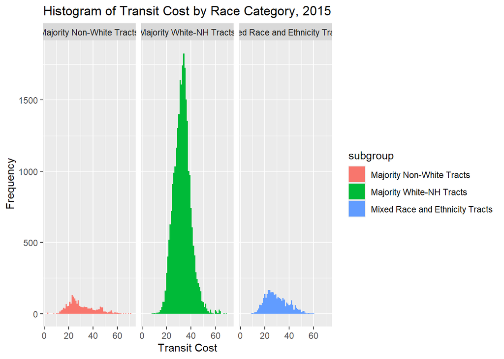

```r
ggplot(subset(cost_by_race_15, index_transportation_cost>0), aes(x = index_transportation_cost, fill = subgroup)) +
  geom_histogram(binwidth = 1) +
  labs(title = "Histogram of Transit Cost by Race Category, 2015",
       x = "Transit Cost",
       y = "Frequency") +
  facet_wrap(~subgroup, scales = "fixed")
```

Looks about right – similar range across all three groups, way more majority-White tracts (as expected)

Look at summary stats

```r
summary_by_race <- cost_by_race_15 %>%
  group_by(subgroup) %>%
  summarise(
    count = n(),
    mean = mean(index_transportation_cost, na.rm = TRUE),
    median = median(index_transportation_cost, na.rm = TRUE),
    min = min(index_transportation_cost, na.rm = TRUE),
    max = max(index_transportation_cost, na.rm = TRUE),
    sd = sd(index_transportation_cost, na.rm = TRUE)
  )
```

```r
print(summary_by_race)
```

```
# A tibble: 3 x 7
  subgroup                        count  mean median   min   max    sd
  <chr>                           <int> <dbl>  <dbl> <dbl> <dbl> <dbl>
1 Majority Non-White Tracts       29318  30.6   27.9  3       71 11.3
2 Majority White-NH Tracts        29318  32.8   33    8.48    69  6.85
3 Mixed Race and Ethnicity Tracts 29318  29.7   28    8.74    60  9.11
```

Examine outliers.

```r
cost_by_race_2015_outliers <- cost_by_race_15 %>%
  filter(index_transportation_cost>100)
```

Nothing unexpected,

Use stopifnot to check if all values are non-negative.

```r
stopifnot(min(cost_by_race_15$index_transportation_cost, na.rm = TRUE) >= 0)
```

Good to go.

### Cost 2019

Look at histograms County-Level Transit Cost 2019 by Race Category (look at transit costs below $250 so we can actually see something; above 250, we have already explored outliers above)

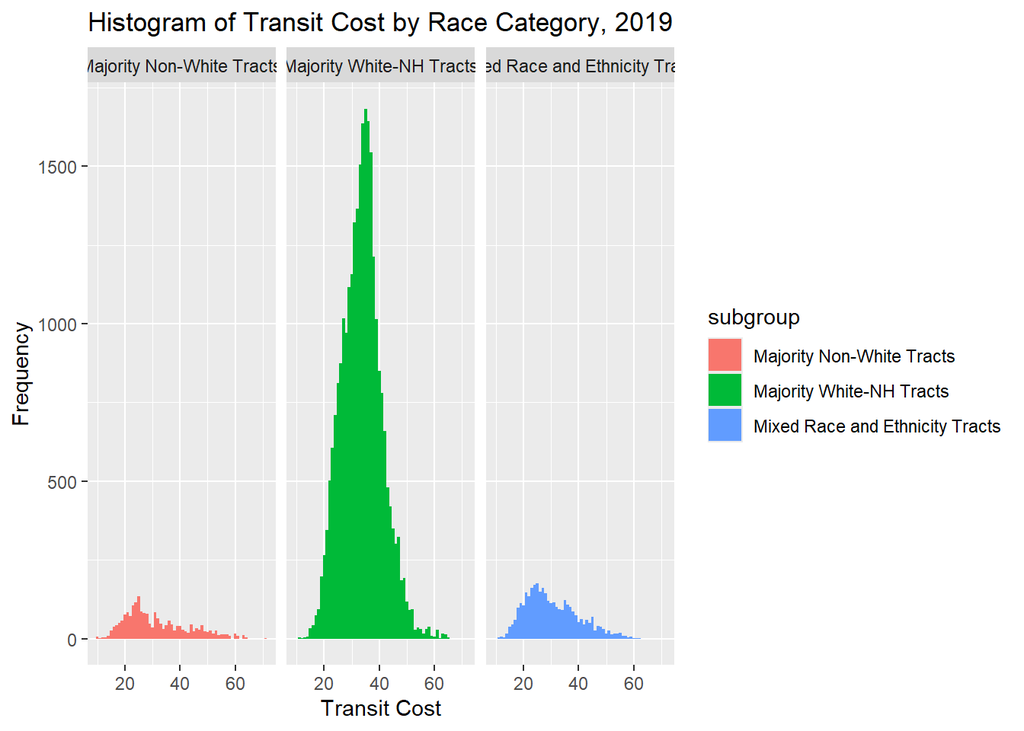

```r
ggplot(subset(cost_by_race_19, index_transportation_cost>0), aes(x = index_transportation_cost, fill = subgroup)) +
  geom_histogram(binwidth = 1) +
  labs(title = "Histogram of Transit Cost by Race Category, 2019",
       x = "Transit Cost",
       y = "Frequency") +
  facet_wrap(~subgroup, scales = "fixed")
```

Looks about right – similar range across all three groups, way more majority-White tracts (as expected)

Look at summary stats

```r
summary_by_race <- cost_by_race_19 %>%
  group_by(subgroup) %>%
  summarise(
    count = n(),
    mean = mean(index_transportation_cost, na.rm = TRUE),
    median = median(index_transportation_cost, na.rm = TRUE),
    min = min(index_transportation_cost, na.rm = TRUE),
    max = max(index_transportation_cost, na.rm = TRUE),
    sd = sd(index_transportation_cost, na.rm = TRUE)
  )
```

```r
print(summary_by_race)
```

```
# A tibble: 3 x 7
  subgroup                        count  mean median   min   max    sd
  <chr>                           <int> <dbl>  <dbl> <dbl> <dbl> <dbl>
1 Majority Non-White Tracts       29318  31.4   28    10      71 11.5
2 Majority White-NH Tracts        29318  33.7   34    10.6    65  7.29
3 Mixed Race and Ethnicity Tracts 29318  30.4   28.5  10.9    62  9.58
```

Examine outliers

```r
cost_by_race_2019_outliers <- cost_by_race_19 %>%
  filter(index_transportation_cost>100)
```

Nothing unexpected

Use stopifnot to check if all values are non-negative

```r
stopifnot(min(cost_by_race_19$index_transportation_cost, na.rm = TRUE) >= 0)
```

Good to go.

### Trips 2015

Look at histograms County-Level Transit Trips 2015 by Race Category (look at transit costs below 100 trips so we can actually see something; above 100, we have already explored outliers above)

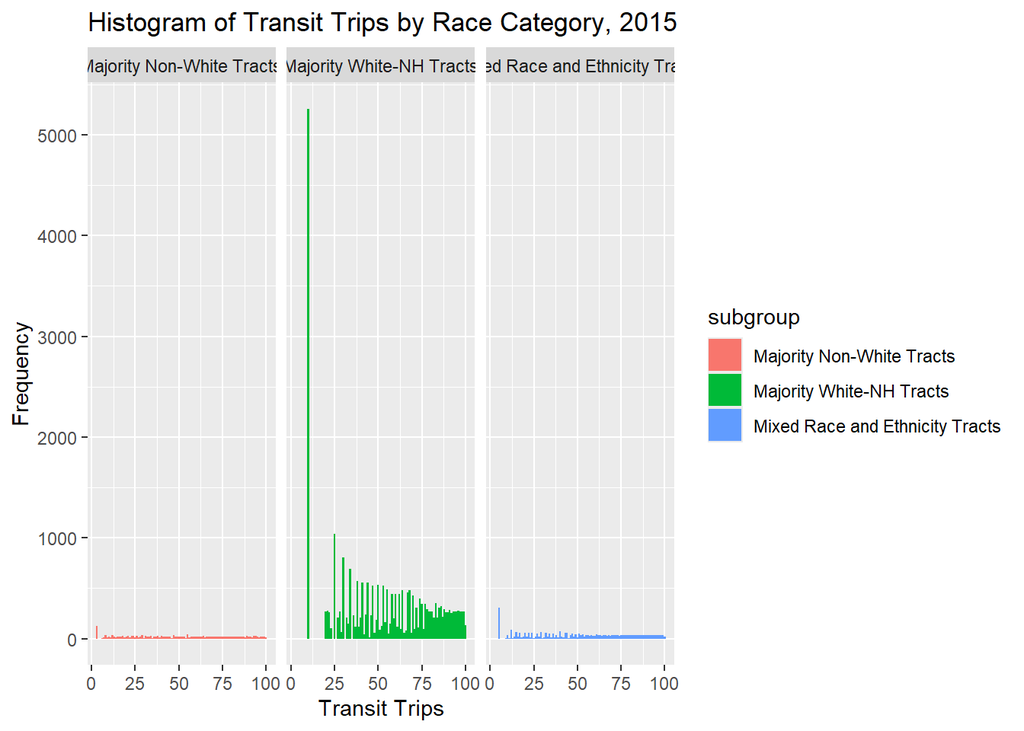

```r
ggplot(subset(trips_by_race_15, index_transit_trips>0), aes(x = index_transit_trips, fill = subgroup)) +
  geom_histogram(binwidth = 1) +
  labs(title = "Histogram of Transit Trips by Race Category, 2015",
       x = "Transit Trips",
       y = "Frequency") +
  facet_wrap(~subgroup, scales = "fixed")
```

Look at summary stats.

```r
summary_by_race <- trips_by_race_15 %>%
  group_by(subgroup) %>%
  summarise(
    count = n(),
    mean = mean(index_transit_trips, na.rm = TRUE),
    median = median(index_transit_trips, na.rm = TRUE),
    min = min(index_transit_trips, na.rm = TRUE),
    max = max(index_transit_trips, na.rm = TRUE),
    sd = sd(index_transit_trips, na.rm = TRUE)
  )
```

```r
print(summary_by_race)
```

```
# A tibble: 3 x 7
  subgroup                        count  mean median   min   max    sd
  <chr>                           <int> <dbl>  <dbl> <dbl> <dbl> <dbl>
1 Majority Non-White Tracts       29318  50.0   50.0  3.14  100   28.9
2 Majority White-NH Tracts        29318  50.0   50.2  9.74  100.  28.8
3 Mixed Race and Ethnicity Tracts 29318  50.0   50    4.62  100   28.9
```

Examine outliers.

```r
trips_by_race_2015_outliers <- trips_by_race_15 %>%
  filter(index_transit_trips>100)
```

Nothing unexpected

Use stopifnot to check if all values are non-negative.

```r
stopifnot(min(trips_by_race_15$index_transit_trips, na.rm = TRUE) >= 0)
```

Good to go

### Trips 2019

Look at histograms

County-Level Transit Trips 2019 by Race Category (look at transit trips below 100 so we can actually see something; above 100, we have already explored outliers above)

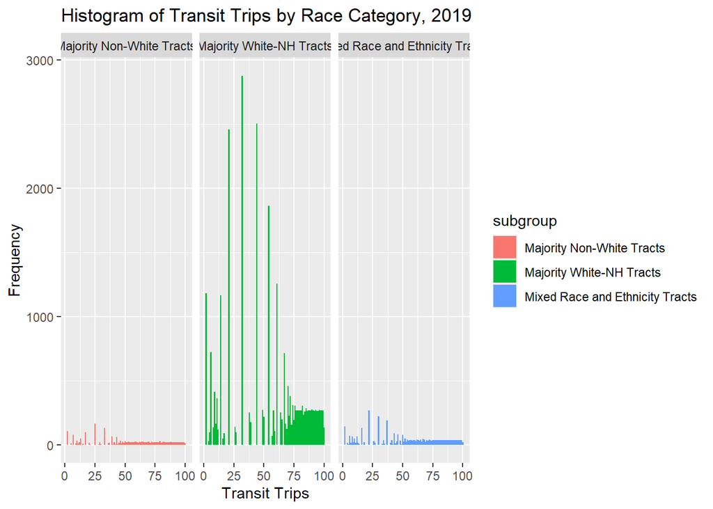

```r
ggplot(subset(trips_by_race_19, index_transit_trips>0), aes(x = index_transit_trips, fill = subgroup)) +
  geom_histogram(binwidth = 1) +
  labs(title = "Histogram of Transit Trips by Race Category, 2019",
       x = "Transit Trips",
       y = "Frequency") +
  facet_wrap(~subgroup, scales = "fixed")
```

Look at summary stats.

```r
summary_by_race <- trips_by_race_19 %>%
  group_by(subgroup) %>%
  summarise(
    count = n(),
    mean = mean(index_transit_trips, na.rm = TRUE),
    median = median(index_transit_trips, na.rm = TRUE),
    min = min(index_transit_trips, na.rm = TRUE),
    max = max(index_transit_trips, na.rm = TRUE),
    sd = sd(index_transit_trips, na.rm = TRUE)
  )
```

```r
print(summary_by_race)
```

```
# A tibble: 3 x 7
  subgroup                        count  mean median   min   max    sd
  <chr>                           <int> <dbl>  <dbl> <dbl> <dbl> <dbl>
1 Majority Non-White Tracts       29318  50.0   49.6  2.47   100  28.9
2 Majority White-NH Tracts        29318  50.0   50.0  2.2    100  28.8
3 Mixed Race and Ethnicity Tracts 29318  50.0   49.7  2.06   100  28.9
```

Examine outliers.

```r
trips_by_race_2019_outliers <- trips_by_race_19 %>%
  filter(index_transit_trips>100)
```

Nothing unexpected

Use stopifnot to check if all values are non-negative.

```r
stopifnot(min(trips_by_race_19$index_transit_trips, na.rm = TRUE) >= 0)
```

Good to go

## Export files

Combine the All values with the Subgroup values by appending

```r
cost_race_15 <- bind_rows(cost_all_15, cost_by_race_15)
cost_race_19 <- bind_rows(cost_all_19, cost_by_race_19)
trips_race_15 <- bind_rows(trips_all_15, trips_by_race_15)
trips_race_19 <- bind_rows(trips_all_19, trips_by_race_19)
```

Add a variable for the year of the data.

```r
cost_race_15 <- cost_race_15 %>%
  mutate(
    year = 2015
  )
cost_race_19 <- cost_race_19 %>%
  mutate(
    year = 2019
  )
trips_race_15 <- trips_race_15 %>%
  mutate(
    year = 2015
  )
trips_race_19 <- trips_race_19 %>%
  mutate(
    year = 2019
  )
```

Combine the two years into one overall files for both variables

```r
transit_cost_subgroup_city <- rbind(cost_race_15, cost_race_19)
transit_trips_subgroup_city <- rbind(trips_race_15, trips_race_19)
```

Keep variables of interest and order them appropriately

```r
transit_trips_subgroup_city <- transit_trips_subgroup_city %>%
  select(year, state, place, subgroup_type, subgroup, index_transit_trips, index_transit_trips_quality) %>%
  arrange(year, state, place, subgroup_type, subgroup)
transit_cost_subgroup_city <- transit_cost_subgroup_city %>%
  select(year, state, place, subgroup_type, subgroup, index_transportation_cost, index_transportation_cost_quality) %>%
  arrange(year, state, place, subgroup_type, subgroup)
```

Keep only our cities of interest (486 of them from the places crosswalk)

```r
places <- read_csv(here::here("geographic-crosswalks",
                              "data",
                              "place-populations.csv"))
```

keep the most recent year

```r
places <- places %>%
  filter(year == 2019) %>%
  select(state, place)
```

Left join to limit to places of interest

```r
transit_trips_subgroup_city <- left_join(places, transit_trips_subgroup_city, by = c("state", "place"))
```

234,544 obs to 3867 obs

```r
transit_cost_subgroup_city <- left_join(places, transit_cost_subgroup_city, by = c("state", "place"))
```

234,544 obs to 3867 obs

Another place expander to account for the difference between 3867 and 3888 (what the count should be if all places accounted for)

```r
place_expander <- expand_grid(
  count(places, state, place) %>% select(-n),
  race_category = c("All", "Majority White-NH Tracts", "Majority Non-White Tracts", "Mixed Race and Ethnicity Tracts")
)
```

1944 obs.

```r
duplicated_expander <- bind_rows(place_expander, place_expander) %>%
  mutate(year = ifelse(row_number() <= nrow(place_expander), 2015, 2019)) %>%
  mutate(subgroup_type = "race-ethnicity") %>%
  rename(subgroup = race_category)
```

Merge back in to account for missings.

```r
transit_trips_subgroup_city <- left_join(duplicated_expander, transit_trips_subgroup_city, by = c("year", "state", "place", "subgroup_type", "subgroup")) %>%
  arrange (year, state, place, subgroup_type, subgroup, index_transit_trips, index_transit_trips_quality) %>%
  select(year, state, place, subgroup_type, subgroup, index_transit_trips, index_transit_trips_quality)

transit_cost_subgroup_city <- left_join(duplicated_expander, transit_cost_subgroup_city, by = c("year", "state", "place", "subgroup_type", "subgroup")) %>%
  arrange (year, state, place, subgroup_type, subgroup, index_transportation_cost, index_transportation_cost_quality) %>%
  select(year, state, place, subgroup_type, subgroup, index_transportation_cost, index_transportation_cost_quality)
```

3867 obs to 3888 obs.

Save as non-subgroup all-year files

```r
write_csv(transit_trips_subgroup_city, here::here("06_neighborhoods",
                                                  "Transportation",
                                                  "final",
                                                  "transit_trips_all_subgroups_city.csv"))

write_csv(transit_cost_subgroup_city, here::here("06_neighborhoods",
                                                 "Transportation",
                                                 "final",
                                                 "transit_cost_all_subgroups_city.csv"))
```